# 02 Exercises

# Conceptual

1. For each of parts (a) through (d), indicate whether we would generally expect the performance of a flexible statistical learning method to be better or worse than an inflexible method. Justify your answer.
   1. The sample size n is extremely large, and the number of predictors p is small.

      ```
      n being large provides us with a better representation of the model.
      p being small limits the amount of variance as there are only a few predictors.

      Based on these 2 facts, a flexible method will fare better than an inflexible approach.
      ```

   2. The number of predictors p is extremely large, and the number of observations n is small.

      ```
      n is small implies there is not enough data to train the model with leading to overfitting with a
      flexible method.
      p being large increases the amount of variance within the model due to the large number of predictors.

      Based on this, a flexible approach will fare worse than an inflexible method.
      ```

   3. The relationship between the predictors and response is highly non-linear.

      ```
      A non-linear relationship implies more degrees of freedom which suits a flexible approach.

      Linear relationships, on the other hand, generally suit non-flexible methods.
      ```

   4. The variance of the error terms, i.e. $\sigma^2$ = Var($\epsilon$), is extremely high.

      ```
      As there is high variance of the error terms, there is a lot of noise in the data.

      This leads to a flexible method faring much worse as it tries to adapt to the noise.
      ```

2. Explain whether each scenario is a classification or regression problem, and indicate whether we are most interested in inference or prediction. Finally, provide n and p.
   1. We collect a set of data on the top 500 firms in the US. For each firm we record profit, number of employees, industry and the CEO salary. We are interested in understanding which factors affect CEO salary.

      ```
      Classification/Regression: Regression
      Inference/Prediction: Inference (what factors affect the CEO salary)
      n: 500
      p: 3 (profit, number of employees, industry)
      ```

   2. We are considering launching a new product and wish to know whether it will be a success or a failure. We collect data on 20 similar products that were previously launched. For each product we have recorded whether it was a success or failure, price charged for the product, marketing budget, competition price, and ten other variables.

      ```
      Classification/Regression: Classification
      Inference/Prediction: Prediction (is the product a success or failure)
      n: 20
      p: 13 (price charged for product, marketing budget, competition price, and 10 other variables)
      ```

   3. We are interested in predicting the % change in the USD/Euro exchange rate in relation to the weekly changes in the world stock markets. Hence we collect weekly data for all of 2012. For each week we record the % change in the USD/Euro, the % change in the US market, the % change in the British market, and the % change in the German market.

      ```
      Classification/Regression: Regression
      Inference/Prediction: Prediction (% change in the USD/Euro exchange rate)
      n: 52 (weeks in 2012)
      p: 3 (% change in the US market, % change in the British market, and % change in the German market)
      ```

3. We now revisit the bias-variance decomposition.
   1. Provide a sketch of typical (squared) bias, variance, training error, test error, and Bayes (or irreducible) error curves, on a single plot, as we go from less flexible statistical learning methods towards more flexible approaches. The x-axis should represent the amount of flexibility in the method, and the y-axis should represent the values for each curve. There should be five curves. Make sure to label each one.

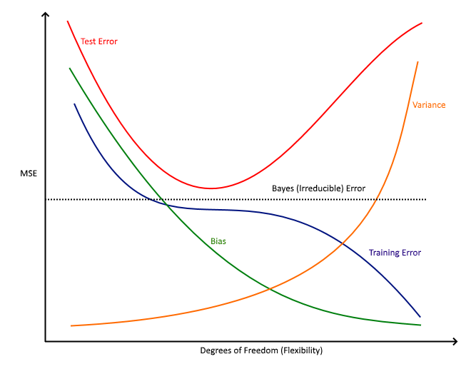

   2. Explain why each of the five curves has the shape displayed in part (a).

      ```
      All 5 curves or lines have a Mean Squared Error (MSE) > 0.

      BIAS - decreases monotonically as with increases in flexibility, a closer fit is obtained.

      VARIANCE - increases monotonically as with increases in flexibility, overfitting occurs.

      TRAINING ERROR - Always decreases with flexibility.  Overfitting results in a lower MSE with training
      data.

      TEST ERROR - Shows the interaction between BIAS and VARIANCE.  First decreases as BIAS decreases and
      VARIANCE is low.  Then increases with VARIANCE.

      BAYES (IRREDUCIBLE) ERROR - Defines the lower limit.  The TEST ERROR is bounded below by the
      IRREDUCIBLE ERROR due to variance in the error (epsilon) in the output values (0 <= value). When the
      TRAINING ERROR is lower than the IRREDUCIBLE ERROR, overfitting takes place.  The BAYES ERROR RATE is
      defined for classification problems and is determined by the ratio of data points which lie at the
      "wrong" side of the decision boundary, (0 <= value < 1).
      ```

4. You will now think of some real-life applications for statistical learning.
   1. Describe three real-life applications in which classification might be useful. Describe the response, as well as the predictors. Is the goal of each application inference or prediction? Explain your answer.

      ```
      Direction of stock price. Prediction problem with predictors like the closing price for day - 1,
      day - 2, etc., trading volume, closing price details of closest 2 competitors in the same industry.

      Why is a person sick or healthy? Inference problem with predictors like heart rate, blood pressure,
      height, weight.

      Spam email or not. Prediction problem with predictors like word frequency, length of sentence,
      spelling errors, word count.
      ```

   2. Describe three real-life applications in which regression might be useful. Describe the response, as well as the predictors. Is the goal of each application inference or prediction? Explain your answer.

      ```
      House prices. Prediction problem with predictors like area, number of bedrooms, neighborhood,
      school nearby.

      Salary of a CEO. Inference problem with predictors like age, experience, education, knowledge of
      industry.

      Closing price of a stock. Prediction problem with predictors like the closing price for day - 1,
      day - 2, etc., trading volume, closing price details of closest 2 competitors in the same industry.
      ```

   3. Describe three real-life applications in which cluster analysis might be useful.

      ```
      Market segmentation using customer demographics.

      Movie recommendations based on viewing habits.

      Cancer Types based on DNA analysis.
      ```

5. What are the advantages and disadvantages of a very flexible (versus a less flexible) approach for regression or classification? Under what circumstances might a more flexible approach be preferred to a less flexible approach? When might a less flexible approach be preferred?

   ```
   A flexible approach makes fewer assumptions and provides a better fit to the data. However, the fact that
   there are very few assumptions made makes the model harder to interpret. Also, it may be prone to
   overfitting.

   A more flexible approach would be preferred to a less flexible approach when we are interested in prediction
   and not the interpretability of the results.

   A less flexible approach would be preferred to a more flexible approach when we are interested in inference
   and the interpretability of the results.
   ```

6. Describe the differences between a parametric and a non-parametric statistical learning approach. What are the advantages of a parametric approach to regression or classification (as opposed to a nonparametric approach)? What are its disadvantages?

   ```
   A parametric approach reduces the problem of estimating f down to one of estimating a set of parameters
   because it assumes a form for f.

   A non-parametric approach does not assume a functional form for f and so requires a very large number of
   observations to accurately estimate f.

   The advantages of a parametric approach to regression or classification are the simplifying of modeling f
   to a few parameters and not as many observations are required compared to a non-parametric approach.

   The disadvantages of a parametric approach to regression or classification are a potential to inaccurately
   estimate f if the form of f assumed is wrong or to overfit the observations if more flexible models are
   used.
   ```

7. The table below provides a training data set containing six observations, three predictors, and one qualitative response variable.

   | Obs. | $X_1$ | $X_2$ | $X_3$ | Y |
   | --- | --- | --- | --- | --- |
   | 1 | 0 | 3 | 0 | Red |
   | 2 | 2 | 0 | 0 | Red |
   | 3 | 0 | 1 | 3 | Red |
   | 4 | 0 | 1 | 2 | Green |
   | 5 | −1 | 0 | 1 | Green |
   | 6 | 1 | 1 | 1 | Red |

   Suppose we wish to use this data set to make a prediction for Y when $X_1 = X_2 = X_3 = 0$ using K-nearest neighbors.
   1. Compute the Euclidean distance between each observation and the test point, $X_1 = X_2 = X_3 = 0$

      ```
      Euclidean Distance = sqrt(sum((x1 - t1)^2 + (x2 - t2)^2 + (x3 - t3)^2)
      ```

      | Obs. | $X_1$ | $X_2$ | $X_3$ | Y | Distance(0,0,0) |
      | --- | --- | --- | --- | --- | --- |
      | 1 | 0 | 3 | 0 | Red | 3.0 |
      | 2 | 2 | 0 | 0 | Red | 2.0 |
      | 3 | 0 | 1 | 3 | Red | 3.2 |
      | 4 | 0 | 1 | 2 | Green | 2.2 |
      | 5 | −1 | 0 | 1 | Green | 1.4 |
      | 6 | 1 | 1 | 1 | Red | 1.7 |

   2. What is our prediction with K = 1? Why?

      ```
      When K = 1, Y = Green as the nearest neighbor is Obs. 5.
      ```

   3. What is our prediction with K = 3? Why?

      ```
      When K = 3, the nearest neighbors are Obs. 5 (Green), 6 (Red) and 2 (Red).
      Hence, Y = Red for the test point (majority is red).
      ```

   4. If the Bayes decision boundary in this problem is highly nonlinear, then would we expect the best value for K to be large or small? Why?

      ```
      If the Bayes decision boundary is non-linear, then K needs to be small in order to be flexible.

      If K is large, it takes more points into consideration making it more linear than flexible.
      ```